# Lab 1

Nathan Diekema

9/22/2021

### Loading in the data

```r
library(readr);
```

```r
library(ggplot2);
q1data <- read_csv("data/q1data.csv");
q1data <- na.omit(q1data);
head(q1data);
```

| income | life_exp | population | year | country | four_regions | six_regions | eight_regions | world_bank_region |
| --- | --- | --- | --- | --- | --- | --- | --- | --- |
| 1910 | 61.0 | 29200000 | 2010 | Afghanistan | asia | south_asia | asia_west | South Asia |
| 11100 | 78.1 | 2950000 | 2010 | Albania | europe | europe_central_asia | europe_east | Europe & Central Asia |
| 11100 | 74.7 | 36000000 | 2010 | Algeria | africa | middle_east_north_africa | africa_north | Middle East & North Africa |
| 46900 | 81.9 | 84500 | 2010 | Andorra | europe | europe_central_asia | europe_west | Europe & Central Asia |
| 7680 | 60.8 | 23400000 | 2010 | Angola | africa | sub_saharan_africa | africa_sub_saharan | Sub-Saharan Africa |
| 17600 | 76.0 | 88000 | 2010 | Antigua and Barbuda | americas | america | america_north | Latin America & Caribbean |

```r
theme_set(theme_bw());
```

## **Task 1**

Adaption of Gapminder 2010 data visualization.

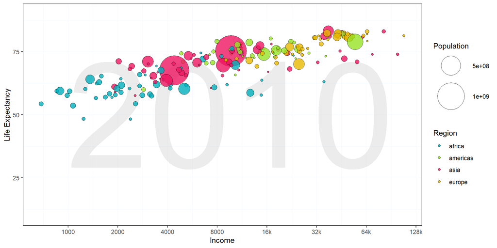

Figure 1: Adaption of Gapminder 2010 data visualization

```r
q1plot <- ggplot(data = q1data, mapping = aes(x = income, y = life_exp, size = population, fill=four_regions)) +
  annotate(geom = 'text',
           x = median(q1data$income) - 1100,
           y = 50,
           label = "2010",
           color="gray",
           size = 75,
           alpha = 0.3) +
  geom_point(color="black", stroke=0.5, shape=21, alpha=0.8) +
  ylim(10,90) +
  scale_fill_manual(values = c("#00AFBB", "#97e424", "#Ee1560", "#E7B800"), name="Region") +
  scale_size(range = c(1,21), name="Population") +
  scale_x_continuous(breaks= c(500,1000,2000,4000,8000,16000,32000,64000,128000),
                     labels=c("500","1000","2000","4000","8000","16k","32k","64k","128k"),
                     trans='log2') +
  ylab("Life Expectancy") +
  xlab("Income") +
  theme(legend.position="right",
        panel.background = element_rect(fill = "white",
                                colour = "black",
                                size = 0.3, linetype = "solid"),
        panel.grid.major = element_line(size = 0.3, linetype = 'solid',
                                colour = "aliceblue"),
        panel.grid.minor = element_line(size = 0.3, linetype = 'solid',
                                colour = "aliceblue")
        )
q1plot
```

Q: *What other geometries could you use here besides geom_point? Why is it good or bad for visualizing data?*

A: Another possible geom that could be used is geom_jitter I have graphed the same data as above using geom_jitter as you can see below. The two graphs are nearly identical so it’s hard to say which is better. The one thing about the jitter plot is that it adds a small amount of random noise to the data points so the data points on a jitter plot do not exactly represent the data in the data set but it is still close enough to illustrate the data well. From my research, a bubble chart is the best way to effectively display three different continuous variables from a dataset like this so geom_jitter gives another medium of creating a similar bubble chart.

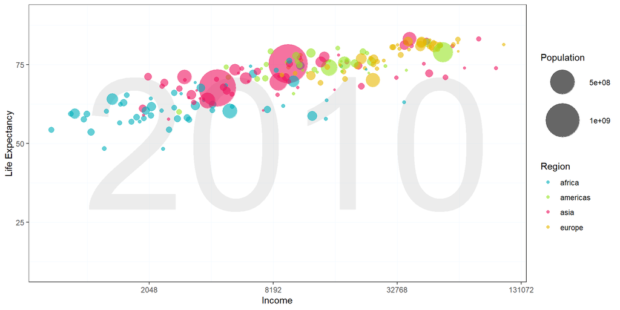

```r
q1bonus <- ggplot(data = q1data, mapping = aes(x = income, y = life_exp, size = population, color=four_regions)) +
  annotate(geom = 'text',
           x = median(q1data$income) - 1100,
           y = 50,
           label = "2010",
           color="gray",
           size = 75,
           alpha = 0.3) +
  geom_jitter(alpha=0.6) +
  ylim(10,90) +
  scale_color_manual(values = c("#00AFBB", "#97e424", "#Ee1560", "#E7B800"), name="Region") +
  scale_size(range = c(1,21), name="Population") +
  scale_x_continuous(trans='log2') +
  ylab("Life Expectancy") +
  xlab("Income") +
  theme(legend.position="right",
        panel.background = element_rect(fill = "white",
                                colour = "black",
                                size = 0.3, linetype = "solid"),
        panel.grid.major = element_line(size = 0.3, linetype = 'solid',
                                colour = "aliceblue"),
        panel.grid.minor = element_line(size = 0.3, linetype = 'solid',
                                colour = "aliceblue")
        )
q1bonus
```

## **Task 2**

Adaption of Gapminder 1997 data visualization.

```r
q2data <- read_csv("data/q2data.csv");
q2data <- na.omit(q2data);
head(q2data)
```

| imports | exports | energy | year | country | four_regions | six_regions | eight_regions | world_bank_region |
| --- | --- | --- | --- | --- | --- | --- | --- | --- |
| 36.7 | 11.5 | 427 | 1997 | Albania | europe | europe_central_asia | europe_east | Europe & Central Asia |
| 22.5 | 22.6 | 825 | 1997 | Algeria | africa | middle_east_north_africa | africa_north | Middle East & North Africa |
| 12.9 | 10.4 | 1660 | 1997 | Argentina | americas | america | america_south | Latin America & Caribbean |
| 52.8 | 19.0 | 610 | 1997 | Armenia | europe | europe_central_asia | europe_east | Europe & Central Asia |
| 20.5 | 19.6 | 5550 | 1997 | Australia | asia | east_asia_pacific | east_asia_pacific | East Asia & Pacific |
| 38.6 | 38.4 | 3610 | 1997 | Austria | europe | europe_central_asia | europe_west | Europe & Central Asia |

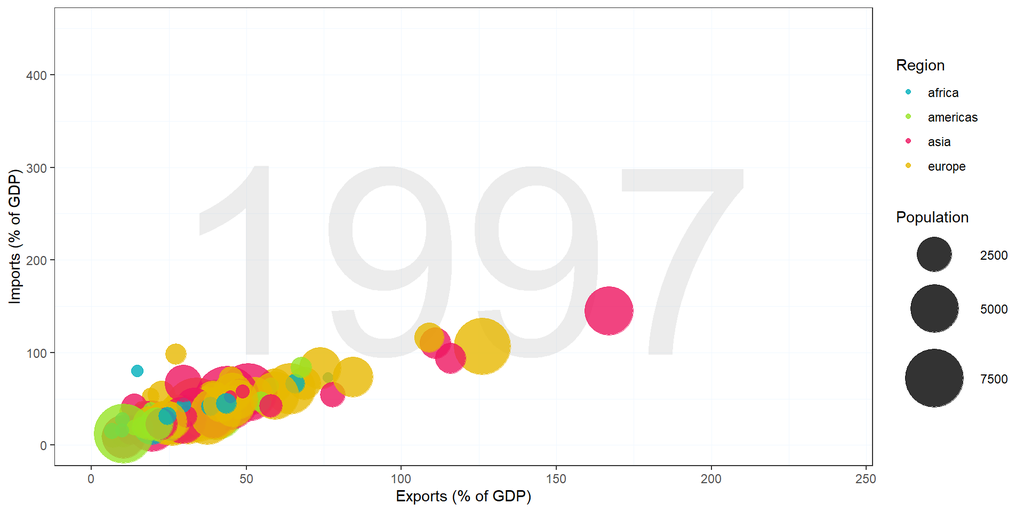

```r
q2plot <- ggplot(data = q2data, mapping = aes(x = exports,
                                              y = imports,
                                              size = as.numeric(energy),
                                              color=four_regions)) +
  annotate(geom = 'text',
           x = 120,
           y = 200,
           label = "1997",
           color="gray",
           size = 65,
           alpha = 0.3) +
  geom_point(alpha=0.8) +
  scale_color_manual(values = c("#00AFBB", "#97e424", "#Ee1560", "#E7B800"), name="Region") +
  scale_size(range = c(1,21), name="Population") +
  xlim(0,240) +
  ylim(0,450) +
  ylab("Imports (% of GDP)") +
  xlab("Exports (% of GDP)") +
  theme(legend.position="right",
        panel.background = element_rect(fill = "white",
                                colour = "black",
                                size = 0.3, linetype = "solid"),
        panel.grid.major = element_line(size = 0.3, linetype = 'solid',
                                colour = "aliceblue"),
        panel.grid.minor = element_line(size = 0.3, linetype = 'solid',
                                colour = "aliceblue")
        )

q2plot
```

Q: *What other geometries could you use here besides geom_point? Why is it good or bad for visualizing data?*

A: Another possible geom that could be used is geom_jitter I have graphed the same data as above using geom_jitter as you can see below. The two graphs are nearly identical so it’s hard to say which is better. The one thing about the jitter plot is that it adds a small amount of random noise to the data points so the data points on a jitter plot do not exactly represent the data in the data set but it is still close enough to illustrate the data well.

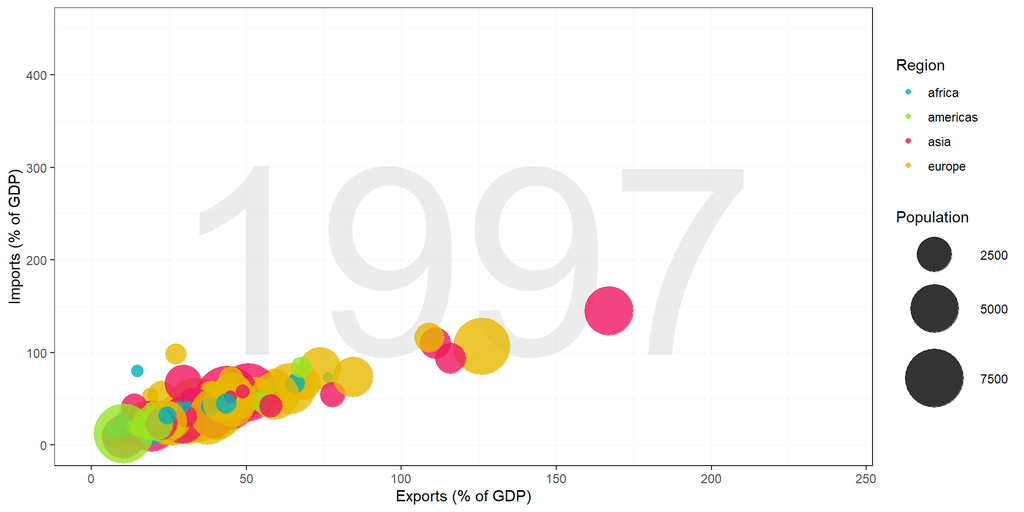

```r
q2bonus <- ggplot(data = q2data, mapping = aes(x = exports,
                                              y = imports,
                                              size = as.numeric(energy),
                                              color=four_regions)) +
  annotate(geom = 'text',
           x = 120,
           y = 200,
           label = "1997",
           color="gray",
           size = 65,
           alpha = 0.3) +
  geom_jitter(alpha=0.8) +
  scale_color_manual(values = c("#00AFBB", "#97e424", "#Ee1560", "#E7B800"), name="Region") +
  scale_size(range = c(1,21), name="Population") +
  xlim(0,240) +
  ylim(0,450) +
  ylab("Imports (% of GDP)") +
  xlab("Exports (% of GDP)") +
  theme(legend.position="right",
        panel.background = element_rect(fill = "white",
                                colour = "black",
                                size = 0.3, linetype = "solid"),
        panel.grid.major = element_line(size = 0.3, linetype = 'solid',
                                colour = "aliceblue"),
        panel.grid.minor = element_line(size = 0.3, linetype = 'solid',
                                colour = "aliceblue")
        )

q2bonus
```

## **Task 3**

Adaption of Gapminder 2001 data visualization.

```r
q3data <- read_csv("data/q3data.csv");
q3data <- na.omit(q3data);
head(q3data)
```

| internet_users | gdp | income | year | country | four_regions | six_regions | eight_regions | world_bank_region |
| --- | --- | --- | --- | --- | --- | --- | --- | --- |
| 0.00456 | 330 | 1190 | 2001 | Afghanistan | asia | south_asia | asia_west | South Asia |
| 0.39000 | 2570 | 6780 | 2001 | Albania | europe | europe_central_asia | europe_east | Europe & Central Asia |
| 1.59000 | 3770 | 9230 | 2001 | Algeria | africa | middle_east_north_africa | africa_north | Middle East & North Africa |
| 11.30000 | 42600 | 35600 | 2001 | Andorra | europe | europe_central_asia | europe_west | Europe & Central Asia |
| 0.27000 | 2440 | 2900 | 2001 | Angola | africa | sub_saharan_africa | africa_sub_saharan | Sub-Saharan Africa |
| 12.50000 | 12300 | 17100 | 2001 | Antigua and Barbuda | americas | america | america_north | Latin America & Caribbean |

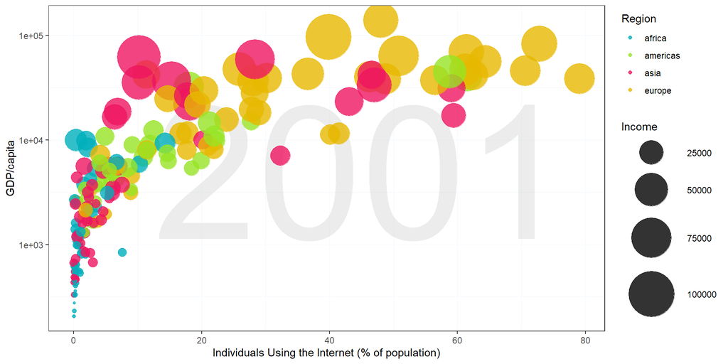

```r
q3plot <- ggplot(data = q3data, mapping = aes(x = internet_users,
                                              y = gdp,
                                              size = as.numeric(income),
                                              color=four_regions)) +
  annotate(geom = 'text',
           x = 45,
           y = 5000,
           label = "2001",
           color="gray",
           size = 65,
           alpha = 0.3) +
  geom_point(alpha=0.8) +
  scale_color_manual(values = c("#00AFBB", "#97e424", "#Ee1560", "#E7B800"), name="Region") +
  scale_size(range = c(1,21), name="Income") +
  scale_y_continuous(trans='log10') +
  ylab("GDP/capita") +
  xlab("Individuals Using the Internet (% of population)") +
  theme(legend.position="right",
        panel.background = element_rect(fill = "white",
                                colour = "black",
                                size = 0.3, linetype = "solid"),
        panel.grid.major = element_line(size = 0.3, linetype = 'solid',
                                colour = "aliceblue"),
        panel.grid.minor = element_line(size = 0.3, linetype = 'solid',
                                colour = "aliceblue")
        )

q3plot
```

**Q: What other geometries could you use here besides geom_point? Provide an actual plot of another geometry being used here and why it’s good or bad for visualizing these data.**

A: Another possible geom that could be used is geom_jitter I have graphed the same data as above using geom_jitter as you can see below. The two graphs are nearly identical so it’s hard to say which is better. The one thing about the jitter plot is that it adds a small amount of random noise to the data points so the data points on a jitter plot do not exactly represent the data in the data set but it is still close enough to illustrate the data well.

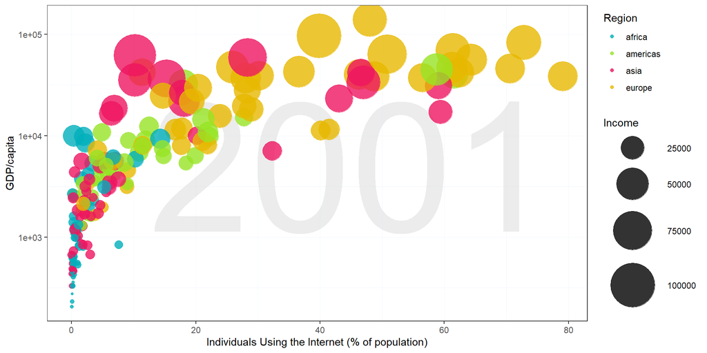

```r
q3bonus <- ggplot(data = q3data, mapping = aes(x = internet_users,
                                              y = gdp,
                                              size = as.numeric(income),
                                              color=four_regions)) +
  annotate(geom = 'text',
           x = 45,
           y = 5000,
           label = "2001",
           color="gray",
           size = 65,
           alpha = 0.3) +
  geom_jitter(alpha=0.8) +
  scale_color_manual(values = c("#00AFBB", "#97e424", "#Ee1560", "#E7B800"), name="Region") +
  scale_size(range = c(1,21), name="Income") +
  scale_y_continuous(trans='log10') +
  ylab("GDP/capita") +
  xlab("Individuals Using the Internet (% of population)") +
  theme(legend.position="right",
        panel.background = element_rect(fill = "white",
                                colour = "black",
                                size = 0.3, linetype = "solid"),
        panel.grid.major = element_line(size = 0.3, linetype = 'solid',
                                colour = "aliceblue"),
        panel.grid.minor = element_line(size = 0.3, linetype = 'solid',
                                colour = "aliceblue")
        )

q3bonus
```